# Feixes Vivos e Drenos Verdes

## Estudo de Caso Pranchas e diagramas técnicos do projeto

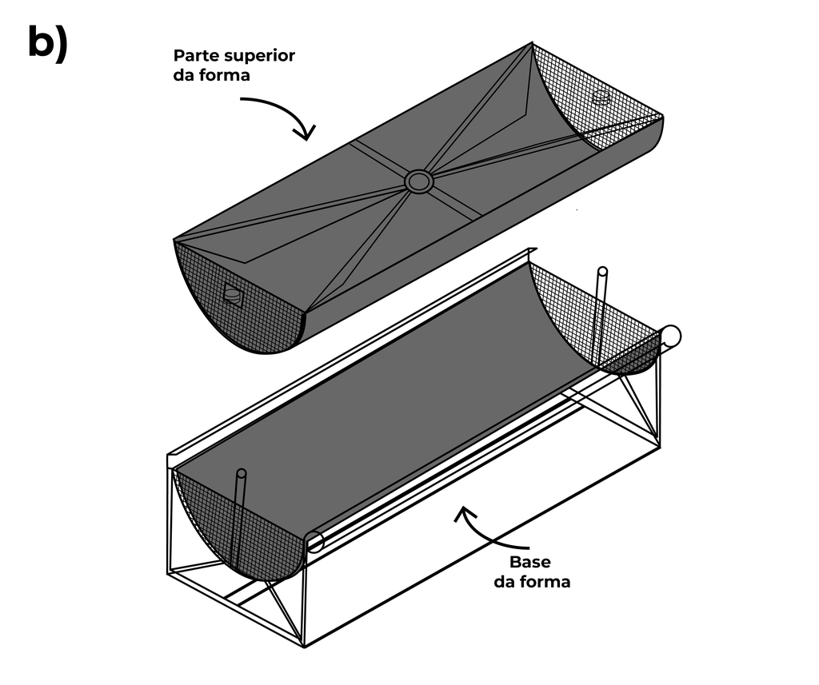

Diagrama técnico do dreno verde

Prancha 01 · Dreno verde Geometria da peça tubular

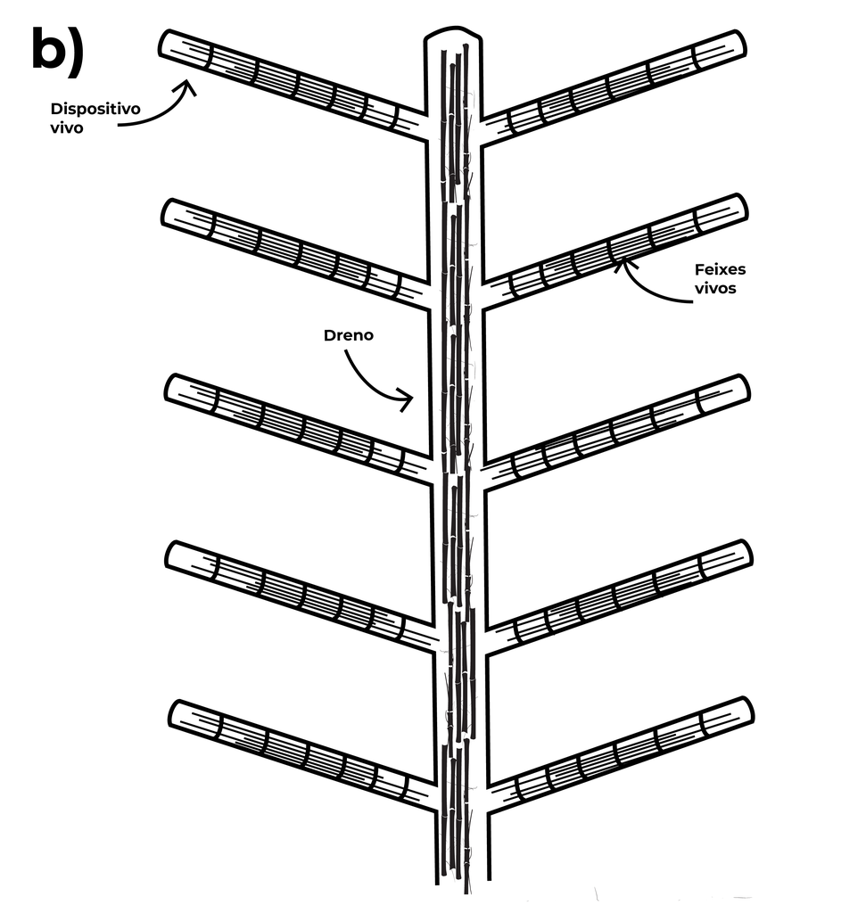

Diagrama de montagem dos componentes

Prancha 02 · Montagem Acoplamento dreno e feixe

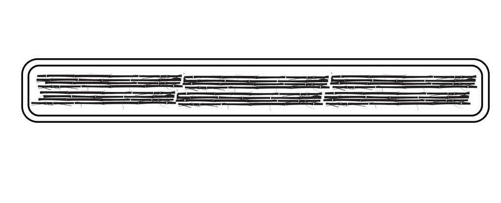

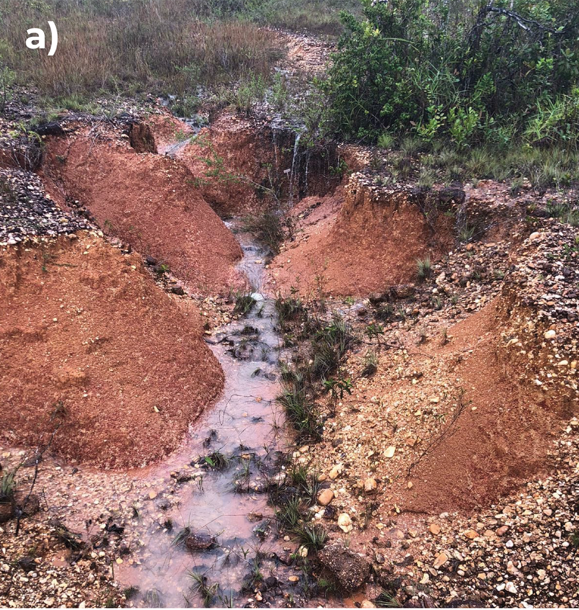

As pranchas técnicas padronizam cortes, conexões e orientação dos feixes para replicação do protocolo em projetos de recuperação de áreas degradadas (PRAD).

## Estudo de Caso Cronograma de monitoramento e indicadores de campo

| Período | Atividade de avaliação |
| --- | --- |
| Dia 0 | Instalação dos drenos verdes e feixes vivos |
| Dias 1–15 | Monitoramento diário de germinação e brotação |
| Dias 15–40 | Avaliação semanal (1º bioensaio) |
| Dia 40 | Transplante para vasos (2º bioensaio) |
| Dias 40–120 | Monitoramento quinzenal em campo |
| Dia 120 | Avaliação final integrada |

Metas de desempenho Indicadores de sucesso

- Taxa de germinação **> 70%**
- Enraizamento **> 80%** das estacas
- Redução expressiva do **escoamento superficial**
- Aumento da **infiltração** e retenção de umidade
- **Estabilidade visível** da encosta ao fim de 120 dias

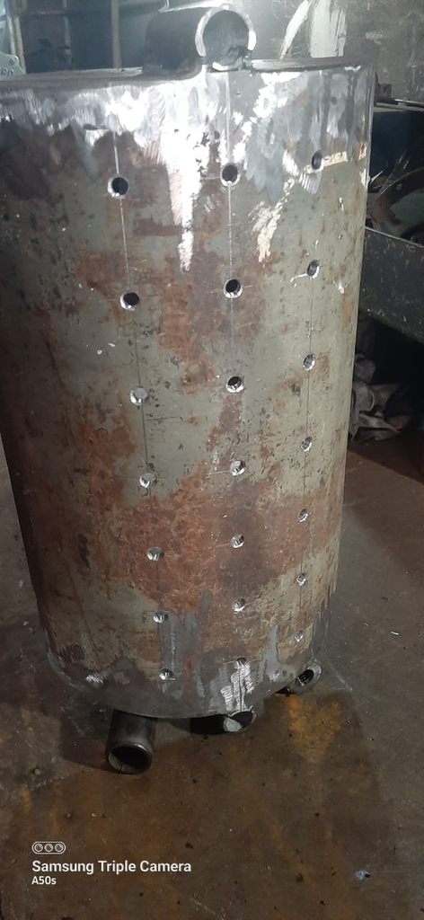

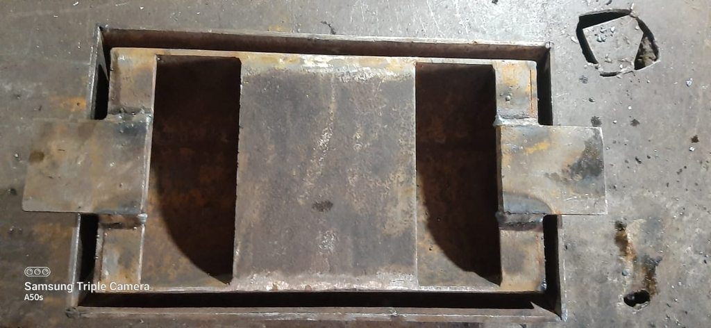

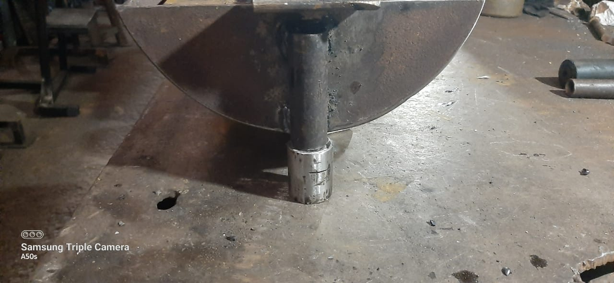

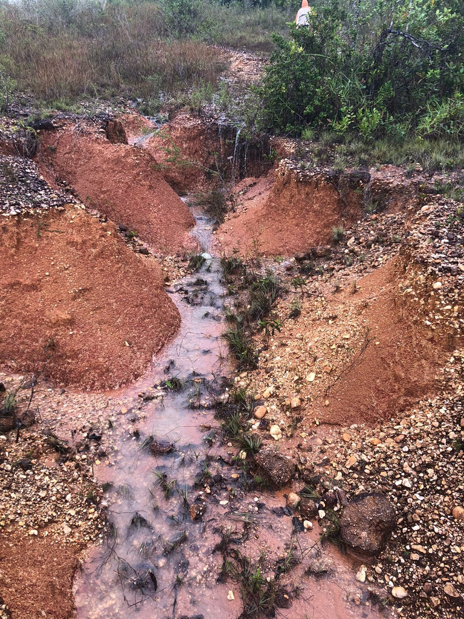

# Síntese e atividade

## Síntese Pontos fundamentais e fluxo conceitual integrado

Síntese da aula Seis pilares técnicos

1. **Seis técnicas de bioengenharia** vegetativa para estabilização de margens e encostas
2. **Drenos verdes** ($\varnothing = 20\text{ cm}$, $\varepsilon = 5\text{ mm}$) integram drenagem e substrato
3. O sistema **espinha de peixe** otimiza captação e condução hidráulica
4. **Fibras de taboa e bananeira** oferecem matriz econômica e biodegradável
5. **7 espécies nativas** com propagação por estaquia comprovada (15–20 cm)
6. **Bioensaios e SAFIRA** quantificam vigor precoce e morfologia radicular

01 · Estruturas Base física

Estacas, feixes, muros vivos, esteiras e drenos verdes.

02 · Espécies Componente vivo

7 espécies nativas em feixes de estacas (15–20 cm).

03 · Arranjo Espinha de peixe

Conexão hidráulica de drenos e fascinas oblíquas.

04 · Resultado Duplo efeito

Estabilização da encosta e restauração ecológica.

## Atividade Projeto em grupo — sistema de drenos verdes

Estudo dirigido · 30 min projeto + 10 min apresentação Cenário: aterro desativado (30 m · 25° · solo argiloso)

Encosta com erosão em sulcos. Projetem um sistema de drenos verdes com feixes vivos respondendo:

1. Quantos **drenos de polo** serão necessários?
2. Qual o **espaçamento** entre as fascinas laterais?
3. Qual o **ângulo** de inserção das fascinas?
4. Quais **3 espécies** escolheriam e por quê?
5. Qual **formulação** de dreno (G1, G2, G3) é mais adequada?
6. Qual o **cronograma de monitoramento** para 120 dias?

| Critério de avaliação | Peso |
| --- | --- |
| Coerência do dimensionamento | 25% |
| Justificativa das espécies | 20% |
| Escolha da formulação | 15% |
| Cronograma de monitoramento | 20% |
| Apresentação e clareza | 20% |

## Referências Referências bibliográficas

Engenharia e bioengenharia Manuais e fundamentos

- Biedenharn, D.S., Elliott, C.M., & Watson, C.C. (1997). *The WES Stream Investigation and Streambank Stabilization Handbook*. USACE.
- Evette, A. et al. (2009). History of Bioengineering Techniques for Erosion Control in Rivers. *Env. Management*, 43(6), 972–984.
- FISRWG (1998). *Stream Corridor Restoration: Principles, Processes, Practices*. USDA-NRCS.
- Gray, D.H. & Sotir, R.B. (1996). *Biotechnical and Soil Bioengineering Slope Stabilization*. Wiley.
- Li, M.H. & Eddleman, K.E. (2002). Biotechnical Engineering as an Alternative. *Landscape Urban Plan.*, 60(4), 225–242.
- Lyn, D.A. & Newton, J.F. (2015). *Approaches to the Design of Biotechnical Streambank Stabilization*. Purdue Univ.
- Morokong, T. & Blignaut, J.N. (2019). Benefits and costs of soil erosion control. *Land Use Policy*, 83, 512–522.
- Rey, F. et al. (2019). Soil and water bioengineering. *Science Total Env.*, 648, 1210–1218.
- USDA-NRCS (1996). *Streambank and Shoreline Protection*. Ch. 16, EFH Part 650.
- USDA-NRCS (2007). *Streambank Soil Bioengineering*. Technical Supplements, NEH Part 654.

Fibras, estaquia e análise radicular Pesquisa aplicada

- Akil, H.M. et al. (2011). Kenaf fiber reinforced composites: A review. *Materials & Design*, 32(8–9), 4107–4121.
- Alqaisi, R., Le, T.M., & Khabbaz, H. (2020). *Applications of Recycled Sustainable Materials in Soil Stabilization*. Springer.
- Araújo Filho, R.N. et al. (2019). Effect of indolebutyric acid on rooting and budding of cuttings. *JEAP*, 297–303.
- Chokshi, S. et al. (2022). Chemical Composition and Mechanical Properties of Natural Fibers. *J. Natural Fibers*, 19(10), 3942–3953.
- Das, P.P. et al. (2021). *Influence of Moisture Uptake on Mechanical Properties of NF-Reinforced Composites*. CRC Press.
- Jorge, L.A.C. & Rodrigues, A.F.O. (2008). *SAFIRA: Sistema de Análise de Fibras e Raízes*. Embrapa.
- Lenz, L. et al. (2019). Bioengenharia de solos como alternativa sustentável. *XXIII SBRH*.
- Santos, L.D.V. et al. (2020). Prospecção tecnológica sobre PD&I em Recursos Hídricos. *Rev. Ibero-Am. Ciências Ambientais*.

Obrigado!

**Prof. Luiz Diego Vidal Santos**

📧 luiz.diego@uefs.br

🌐 ldvsantos.github.io/cv